# Practical Machine Learning Prediction Assignment

Phil Sartor

12/18/2019

# The goal of our project is to predict the manner in which 6 participants did certain exercises.

# Data is taken from accelerometers on the belt, forearm, arm, and dumbell.

# Participants were asked to perform barbell lifts correctly and incorrectly in 5 different ways.

## Set working directory and load required libraries

```r
knitr::opts_chunk$set(echo = TRUE)
library(data.table)
library(caret)
library(knitr)
library(xtable)
library(rpart)
library(randomForest)
```

```r
library(rpart.plot)
library(rattle)
library(gbm)
library(corrplot)
rm(list = ls())
set.seed(54321)
setwd("/Users/psartor/Desktop/Data Management & Analytics/Practical Machine Learning/Week4")
```

## Load and explore the data

```r
# Load and read the training and test data into R using, read.csv function
training  <- read.csv("pml-training.csv", na.strings = c("NA","#DIV/0!",""))
testing <- read.csv("pml-testing.csv", na.strings = c("NA","DIV/0!",""))
dim(training)
```

```
## [1] 19622   160
```

```r
dim(testing)
```

```
## [1]  20 160
```

```r
str(training)
```

```
## 'data.frame':    19622 obs. of  160 variables:
##  $ X                       : int  1 2 3 4 5 6 7 8 9 10 ...
##  $ user_name               : Factor w/ 6 levels "adelmo","carlitos",..: 2 2 2 2 2 2 2 2 2 2 ...
##  $ raw_timestamp_part_1    : int  1323084231 1323084231 1323084231 1323084232 1323084232 1323084232 1323084232 1323084232 1323084232 1323084232 ...
##  $ raw_timestamp_part_2    : int  788290 808298 820366 120339 196328 304277 368296 440390 484323 484434 ...
##  $ cvtd_timestamp          : Factor w/ 20 levels "02/12/2011 13:32",..: 9 9 9 9 9 9 9 9 9 9 ...
##  $ new_window              : Factor w/ 2 levels "no","yes": 1 1 1 1 1 1 1 1 1 1 ...
##  $ num_window              : int  11 11 11 12 12 12 12 12 12 12 ...
##  $ roll_belt               : num  1.41 1.41 1.42 1.48 1.48 1.45 1.42 1.42 1.43 1.45 ...
##  $ pitch_belt              : num  8.07 8.07 8.07 8.05 8.07 8.06 8.09 8.13 8.16 8.17 ...
##  $ yaw_belt                : num  -94.4 -94.4 -94.4 -94.4 -94.4 -94.4 -94.4 -94.4 -94.4 -94.4 ...
##  $ total_accel_belt        : int  3 3 3 3 3 3 3 3 3 3 ...
##  $ kurtosis_roll_belt      : num  NA NA NA NA NA NA NA NA NA NA ...
##  $ kurtosis_picth_belt     : num  NA NA NA NA NA NA NA NA NA NA ...
##  $ kurtosis_yaw_belt       : logi  NA NA NA NA NA NA ...
```

[output cut: 86 more lines]

## The training data set contains 19622 observations and 160 variables, while the testing data set contains 20 observations and 160 variables.

## The “classe” variable in the training set is the outcome to predict.

## There are 5 levels of classe “A”, “B”, “C”, “D”, “E”.

# Clean the data set

## As we can see there are many “NAs” in the dataset.

## We removed any features that contained NA values.

```r
training <- training[, colSums(is.na(training)) == 0]
testing <- testing[, colSums(is.na(testing)) == 0]
```

## Remove columns that do not contribute much to the accelerometer measurements.

```r
classe <- training$classe
trainRemove <- grepl("^X|timestamp|window", names(training))
training <- training[, !trainRemove]
trainCleaned <- training[, sapply(training, is.numeric)]
trainCleaned$classe <- classe
testRemove <- grepl("^X|timestamp|window", names(testing))
testing <- testing[, !testRemove]
testCleaned <- testing[, sapply(testing, is.numeric)]
dim(trainCleaned)
```

```
## [1] 19622    53
```

```r
dim(testCleaned)
```

```
## [1] 20 53
```

## Look for near zero variance data as it can be advantageous to remove the variable from the model.

```r
nzv <- nearZeroVar(trainCleaned, saveMetrics = TRUE)
nzv
```

```
##                      freqRatio percentUnique zeroVar   nzv
## roll_belt             1.101904     6.7781062   FALSE FALSE
## pitch_belt            1.036082     9.3772296   FALSE FALSE
## yaw_belt              1.058480     9.9734991   FALSE FALSE
## total_accel_belt      1.063160     0.1477933   FALSE FALSE
## gyros_belt_x          1.058651     0.7134849   FALSE FALSE
## gyros_belt_y          1.144000     0.3516461   FALSE FALSE
## gyros_belt_z          1.066214     0.8612782   FALSE FALSE
## accel_belt_x          1.055412     0.8357966   FALSE FALSE
## accel_belt_y          1.113725     0.7287738   FALSE FALSE
## accel_belt_z          1.078767     1.5237998   FALSE FALSE
## magnet_belt_x         1.090141     1.6664968   FALSE FALSE
## magnet_belt_y         1.099688     1.5187035   FALSE FALSE
## magnet_belt_z         1.006369     2.3290184   FALSE FALSE
## roll_arm             52.338462    13.5256345   FALSE FALSE
## pitch_arm            87.256410    15.7323412   FALSE FALSE
## yaw_arm              33.029126    14.6570176   FALSE FALSE
## total_accel_arm       1.024526     0.3363572   FALSE FALSE
## gyros_arm_x           1.015504     3.2769341   FALSE FALSE
## gyros_arm_y           1.454369     1.9162165   FALSE FALSE
## gyros_arm_z           1.110687     1.2638875   FALSE FALSE
## accel_arm_x           1.017341     3.9598410   FALSE FALSE
## accel_arm_y           1.140187     2.7367241   FALSE FALSE
## accel_arm_z           1.128000     4.0362858   FALSE FALSE
## magnet_arm_x          1.000000     6.8239731   FALSE FALSE
## magnet_arm_y          1.056818     4.4439914   FALSE FALSE
## magnet_arm_z          1.036364     6.4468454   FALSE FALSE
## roll_dumbbell         1.022388    84.2065029   FALSE FALSE
## pitch_dumbbell        2.277372    81.7449801   FALSE FALSE
## yaw_dumbbell          1.132231    83.4828254   FALSE FALSE
## total_accel_dumbbell  1.072634     0.2191418   FALSE FALSE
## gyros_dumbbell_x      1.003268     1.2282132   FALSE FALSE
## gyros_dumbbell_y      1.264957     1.4167771   FALSE FALSE
## gyros_dumbbell_z      1.060100     1.0498420   FALSE FALSE
## accel_dumbbell_x      1.018018     2.1659362   FALSE FALSE
## accel_dumbbell_y      1.053061     2.3748853   FALSE FALSE
## accel_dumbbell_z      1.133333     2.0894914   FALSE FALSE
## magnet_dumbbell_x     1.098266     5.7486495   FALSE FALSE
## magnet_dumbbell_y     1.197740     4.3012945   FALSE FALSE
## magnet_dumbbell_z     1.020833     3.4451126   FALSE FALSE
## roll_forearm         11.589286    11.0895933   FALSE FALSE
## pitch_forearm        65.983051    14.8557741   FALSE FALSE
## yaw_forearm          15.322835    10.1467740   FALSE FALSE
## total_accel_forearm   1.128928     0.3567424   FALSE FALSE
## gyros_forearm_x       1.059273     1.5187035   FALSE FALSE
## gyros_forearm_y       1.036554     3.7763735   FALSE FALSE
## gyros_forearm_z       1.122917     1.5645704   FALSE FALSE
## accel_forearm_x       1.126437     4.0464784   FALSE FALSE
## accel_forearm_y       1.059406     5.1116094   FALSE FALSE
## accel_forearm_z       1.006250     2.9558659   FALSE FALSE
## magnet_forearm_x      1.012346     7.7667924   FALSE FALSE
## magnet_forearm_y      1.246914     9.5403119   FALSE FALSE
## magnet_forearm_z      1.000000     8.5771073   FALSE FALSE
## classe                1.469581     0.0254816   FALSE FALSE
```

# Partitioning the training set into two datasets

## Next, we can split the cleaned training set into a pure training data set (70%) and a validation data set (30%).

## The training set is used to train or build the model.

## The testing set (or validation set) is used to test or validate the model by estimating the prediction error.

```r
inTrain <- createDataPartition(trainCleaned$classe, p=0.70, list=F)
trainData <- trainCleaned[inTrain, ]
testData <- trainCleaned[-inTrain, ]
```

# Graphical display to visualise the correlation matrix

## In the following graph, positive correlations are displayed in blue and negative correlations in red. Colour intensity is proportional to the correlation coefficients.

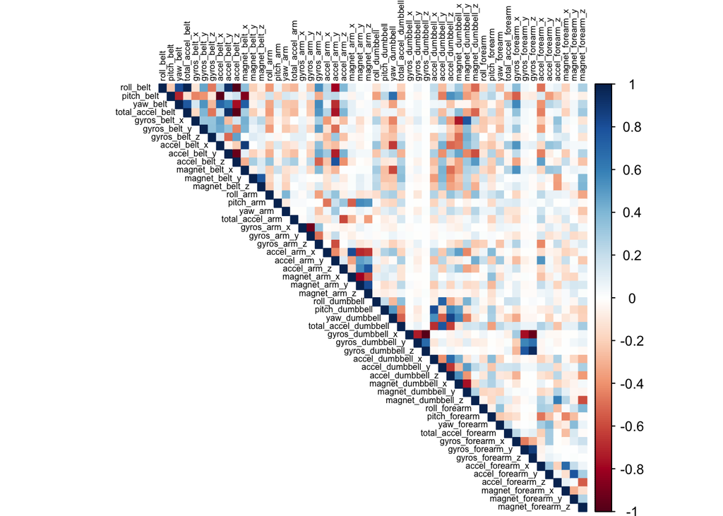

```r
corrPlot <- cor(trainData[, -length(names(trainData))])
corrplot(corrPlot, tl.cex = 0.5, tl.col = rgb(0, 0, 0), method="color", type = "upper")
```

# Prediction model building

## We will use Random Forest, Decision Trees, and the Generalized Boosted Regression Model.

## From this, we will determine the alogorithim that provides the best out-of-sample accuracy.

# Prediction with Random Forest

```r
controlRF <- trainControl(method = "cv", number = 4, verbose = FALSE)
modFitRandForest <- train(classe ~., data = trainData, method = "rf",
                 preProcess = c("center", "scale"),
                 trControl = controlRF)
modFitRandForest
```

```
## Random Forest
##
## 13737 samples
##    52 predictor
##     5 classes: 'A', 'B', 'C', 'D', 'E'
##
## Pre-processing: centered (52), scaled (52)
## Resampling: Cross-Validated (4 fold)
## Summary of sample sizes: 10303, 10303, 10303, 10302
## Resampling results across tuning parameters:
##
##   mtry  Accuracy   Kappa
##    2    0.9906097  0.9881208
##   27    0.9895177  0.9867405
##   52    0.9826748  0.9780817
##
## Accuracy was used to select the optimal model using the largest value.
## The final value used for the model was mtry = 2.
```

## Cross Validation on our testing data

```r
predR <- predict(modFitRandForest, newdata = testData)
RF <- confusionMatrix(predR, testData$classe)
RF$overall["Accuracy"]
```

```
##  Accuracy
## 0.9916737
```

# Prediction with Decision Tree

```r
modFitDecTree <- rpart(classe ~., data = trainData, method = "class")
modFitDecTree
```

```
## n= 13737
##
## node), split, n, loss, yval, (yprob)
##       * denotes terminal node
##
##     1) root 13737 9831 A (0.28 0.19 0.17 0.16 0.18)
##       2) roll_belt< 130.5 12587 8694 A (0.31 0.21 0.19 0.18 0.11)
##         4) pitch_forearm< -34.55 1107    2 A (1 0.0018 0 0 0) *
##         5) pitch_forearm>=-34.55 11480 8692 A (0.24 0.23 0.21 0.2 0.12)
##          10) magnet_dumbbell_y< 436.5 9644 6924 A (0.28 0.18 0.24 0.19 0.11)
##            20) roll_forearm< 122.5 5972 3532 A (0.41 0.18 0.19 0.16 0.061)
##              40) magnet_dumbbell_z< -24.5 2080  690 A (0.67 0.21 0.017 0.075 0.03)
##                80) roll_forearm>=-136.5 1730  377 A (0.78 0.17 0.02 0.025 0.0052) *
##                81) roll_forearm< -136.5 350  204 B (0.11 0.42 0.0029 0.32 0.15) *
##              41) magnet_dumbbell_z>=-24.5 3892 2819 C (0.27 0.17 0.28 0.21 0.078)
##                82) yaw_belt>=168.5 518   77 A (0.85 0.075 0.0019 0.068 0.0039) *
##                83) yaw_belt< 168.5 3374 2302 C (0.18 0.18 0.32 0.23 0.09)
##                 166) accel_dumbbell_y>=-40.5 2910 2141 D (0.21 0.2 0.23 0.26 0.097)
##                   332) pitch_belt< -43.15 319   44 B (0.0094 0.86 0.075 0.028 0.025) *
##                   333) pitch_belt>=-43.15 2591 1831 D (0.23 0.12 0.25 0.29 0.11)
##                     666) roll_belt>=125.5 637  260 C (0.36 0.035 0.59 0.0094 0.0016)
##                      1332) magnet_belt_z< -322.5 203    5 A (0.98 0.0049 0.015 0 0.0049) *
##                      1333) magnet_belt_z>=-322.5 434   60 C (0.076 0.048 0.86 0.014 0) *
##                     667) roll_belt< 125.5 1954 1200 D (0.19 0.15 0.14 0.39 0.14)
##                      1334) pitch_belt>=0.895 1237  956 A (0.23 0.22 0.14 0.22 0.2)
##                        2668) accel_dumbbell_z< 27.5 778  512 A (0.34 0.14 0.21 0.27 0.037)
##                          5336) yaw_forearm>=-90.9 557  291 A (0.48 0.18 0.24 0.065 0.039)
##                           10672) magnet_forearm_z>=-125.5 348   90 A (0.74 0.14 0.011 0.075 0.032) *
##                           10673) magnet_forearm_z< -125.5 209   82 C (0.038 0.25 0.61 0.048 0.053) *
##                          5337) yaw_forearm< -90.9 221   50 D (0 0.032 0.16 0.77 0.032) *
##                        2669) accel_dumbbell_z>=27.5 459  246 E (0.033 0.36 0.0087 0.13 0.46)
##                          5338) roll_dumbbell< 38.61985 170   34 B (0.035 0.8 0.024 0.024 0.12) *
##                          5339) roll_dumbbell>=38.61985 289   96 E (0.031 0.1 0 0.2 0.67) *
##                      1335) pitch_belt< 0.895 717  231 D (0.13 0.025 0.13 0.68 0.042) *
##                 167) accel_dumbbell_y< -40.5 464   57 C (0.0086 0.032 0.88 0.037 0.045) *
##            21) roll_forearm>=122.5 3672 2470 C (0.076 0.18 0.33 0.24 0.18)
##              42) magnet_dumbbell_y< 286.5 2091 1063 C (0.093 0.13 0.49 0.15 0.13)
##                84) magnet_forearm_z< -251 165   34 A (0.79 0.055 0 0.048 0.1) *
##                85) magnet_forearm_z>=-251 1926  898 C (0.033 0.14 0.53 0.16 0.14) *
##              43) magnet_dumbbell_y>=286.5 1581 1034 D (0.054 0.24 0.11 0.35 0.25)
##                86) accel_forearm_x>=-79.5 942  612 E (0.051 0.31 0.16 0.13 0.35)
##                 172) magnet_arm_y>=188.5 384  171 B (0.013 0.55 0.23 0.078 0.12) *
##                 173) magnet_arm_y< 188.5 558  276 E (0.077 0.14 0.11 0.16 0.51) *
##                87) accel_forearm_x< -79.5 639  212 D (0.059 0.14 0.036 0.67 0.097) *
##          11) magnet_dumbbell_y>=436.5 1836  913 B (0.037 0.5 0.046 0.22 0.19)
##            22) total_accel_dumbbell>=5.5 1317  473 B (0.052 0.64 0.063 0.018 0.23)
##              44) roll_belt>=-0.565 1114  270 B (0.061 0.76 0.075 0.022 0.085) *
##              45) roll_belt< -0.565 203    0 E (0 0 0 0 1) *
##            23) total_accel_dumbbell< 5.5 519  133 D (0 0.15 0.0039 0.74 0.1) *
##       3) roll_belt>=130.5 1150   13 E (0.011 0 0 0 0.99) *
```

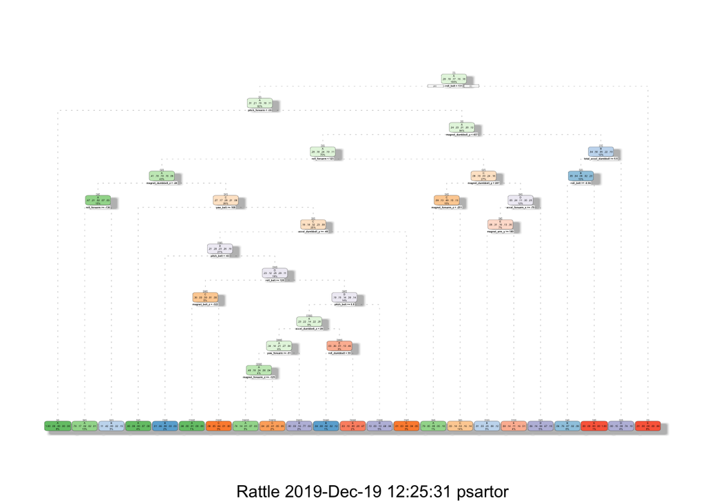

```r
fancyRpartPlot(modFitDecTree)
```

## Cross Validation on our testing data

```r
predD <- predict(modFitDecTree, testData, type = "class")
DT <-confusionMatrix(testData$classe, predD)
DT
```

```
## Confusion Matrix and Statistics
##
##           Reference
## Prediction    A    B    C    D    E
##          A 1482   50   50   60   32
##          B  166  647  182   85   59
##          C   28   93  801   72   32
##          D   56  100  152  595   61
##          E   19   92  132   54  785
##
## Overall Statistics
##
##                Accuracy : 0.7324
##                  95% CI : (0.7209, 0.7436)
##     No Information Rate : 0.2975
##     P-Value [Acc > NIR] : < 2.2e-16
##
##                   Kappa : 0.6611
##
##  Mcnemar's Test P-Value : < 2.2e-16
##
## Statistics by Class:
##
##                      Class: A Class: B Class: C Class: D Class: E
## Sensitivity            0.8464   0.6589   0.6082   0.6871   0.8101
## Specificity            0.9536   0.8997   0.9507   0.9265   0.9396
## Pos Pred Value         0.8853   0.5680   0.7807   0.6172   0.7255
## Neg Pred Value         0.9361   0.9294   0.8938   0.9449   0.9617
## Prevalence             0.2975   0.1669   0.2238   0.1472   0.1647
## Detection Rate         0.2518   0.1099   0.1361   0.1011   0.1334
## Detection Prevalence   0.2845   0.1935   0.1743   0.1638   0.1839
## Balanced Accuracy      0.9000   0.7793   0.7795   0.8068   0.8748
```

```r
DT$overall["Accuracy"]
```

```
##  Accuracy
## 0.7323704
```

# Prediction with Generalized Boosted Regression

```r
modFitBoostRegress <- train(classe ~., data = trainData, method = "gbm",verbose =  FALSE, trControl=trainControl(method = "cv", number = 4))
modFitBoostRegress$finalModel
```

```
## A gradient boosted model with multinomial loss function.
## 150 iterations were performed.
## There were 52 predictors of which 52 had non-zero influence.
```

## Cross Validation on our testing data

```r
predG <- predict(modFitBoostRegress, testData)
GBM <- confusionMatrix(testData$classe, predG)
GBM$overall["Accuracy"]
```

```
##  Accuracy
## 0.9575191
```

# Applying the best model to the provided test set

```r
FinalTestPred <- predict(modFitRandForest, newdata = testCleaned)
FinalTestPred
```

```
##  [1] B A B A A E D B A A B C B A E E A B B B
## Levels: A B C D E
```